# Residual

```r
library(car)
library(tidyverse)
library(mosaic)
library(ggplot2)
library(pander)
library(readr)

laptop <- read_csv("C:/Users/Jae/Desktop/R/Math 325/Statistics-Notebook-master/Statistics-Notebook-master/Data425/laptops.csv",
    col_types = cols(Price_euros = col_number(),
        Weight = col_number()))
```

## Purpose

In this analysis, I am going to tell about `Residual`, `SSE`, `SSR`, `SSTO`, `R_squared (coefficient of determination)`, `adjusted R_squared`, `r(coefficient of correlation)`, and `Residual standard error`.

## Graph

```r
laplm <- lm(Price_euros ~ Weight, data = laptop)
summary(laplm) %>% pander()
```

|  | Estimate | Std. Error | t value | Pr(>\|t\|) |
| --- | --- | --- | --- | --- |
| **(Intercept)** | 673.2 | 61.05 | 11.03 | 4.338e-27 |
| **Weight** | 221 | 28.47 | 7.762 | 1.687e-14 |

Fitting linear model: Price_euros ~ Weight

| Observations | Residual Std. Error | $R^2$ | Adjusted $R^2$ |
| --- | --- | --- | --- |
| 1303 | 683.6 | 0.04426 | 0.04352 |

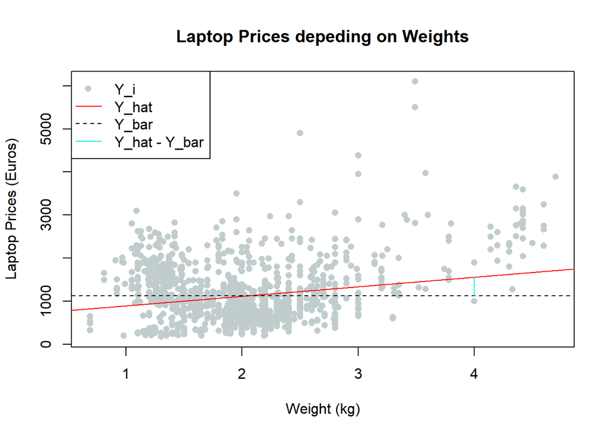

```r
EU <- laptop$Price_euros
EU_hat <- predict(laplm)

plot(Price_euros ~ Weight, data = laptop, pch = 16, col = "azure3", main = "Laptop Prices depeding on Weights", ylab = "Laptop Prices (Euros)", xlab = "Weight (kg)")
abline(laplm, col = "red")
abline(h = mean(EU), col = "black", lty = 2)
segments(x0 = 4,y0 = predict(laplm, data.frame(Weight = 4)), x1 = 4, y1 = 1123.687, col = "cyan2")
legend("topleft", legend = c("Y_i", "Y_hat", "Y_bar", "Y_hat - Y_bar"), lty = c(NA, 1, 2, 1), pch = c(16, NA, NA, NA), col = c("azure3", "red", "black", "cyan2"))
```

## residual, SSE, SSR, SSTO, R_sqaured from the data

```r
Y <- laptop$Price_euros
Y_hat <- predict(laplm)
Y_bar <- mean(Y)

residual <- predict(laplm, data.frame(Weight = 4)) - Y_bar
SSE <- sum((Y - Y_hat)^2)
SSR <- sum((Y_hat - Y_bar)^2)
SSTO <- SSE + SSR
R_squared <- SSR/SSTO
r <- sqrt(R_squared)
MSE <- SSE / 1301

Tab <- matrix(c(residual, SSE, SSR, SSTO, R_squared, r, MSE), ncol = 1, byrow = TRUE)
colnames(Tab) <- c("value")
rownames(Tab) <- c("residual", "SSE", "SSR", "SSTO", "R_squared", "r", "MSE")
Tab <- as.table(Tab)
Tab %>% pander()
```

|  | value |
| --- | --- |
| **residual** | 433.4 |
| **SSE** | 6.08e+08 |
| **SSR** | 28154211 |
| **SSTO** | 636174961 |
| **R_squared** | 0.04426 |
| **r** | 0.2104 |
| **MSE** | 467349 |

$\star$MSE definition: the average squared difference between the estimated values and the actual value.

## Math Equations & Explanations

### Residuals

$$r_i = Y_i - \hat{Y_i}$$
Explanation: Distance of dot to estimated line. Residual showing graph is on the graph of SSE becuase SSE has residuals in its calculation.

### SSE (Sum of Squared Errors)

$$= \Sigma(Y_i - \hat{Y_i})^{2}$$
Explanation: Measures how much the observations deviate from the line. (from dots (data) to the regression line)

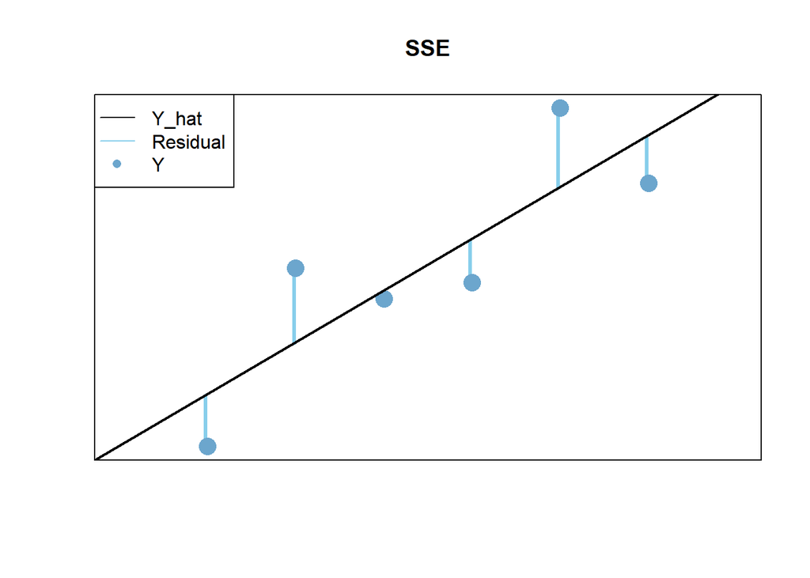

```r
set.seed(19)
x <- c(1, 2, 3, 4, 5, 6)
sigma <- 0.9
epsilon <- rnorm(6, 0, sigma)
beta_0 <- 2
beta_1 <- 0.35
y <- beta_0 + beta_1*x + epsilon
lmr <- lm(y ~ x)

plot(y ~ x, pch=16, col="skyblue3", xlim=c(0,7), cex=2, yaxt='n', xaxt='n', xlab="", ylab="", main="SSE")
for (i in 1:6){
  lines(rep(x[i]-0.02, 2), c(y[i], sum(lmr$coef*c(1,x[i]-0.02))), col="skyblue", lty=1, lwd=3)
}
points(y ~ x, pch=16, col="skyblue3", xlim=c(0,7), cex=2)
abline(lmr, col="black", lwd=2)
legend("topleft", legend = c("Y_hat", "Residual", "Y"), lty = c(1, 1, NA), pch = c(NA, NA, 16), col = c("black", "skyblue", "skyblue3"))
```

## SSR (Sum of Squared Regression)

$$= \Sigma(\hat{Y_i} - \bar{Y})^{2}$$
Explanation: Measures how much the regression line deviates from the average y-value.

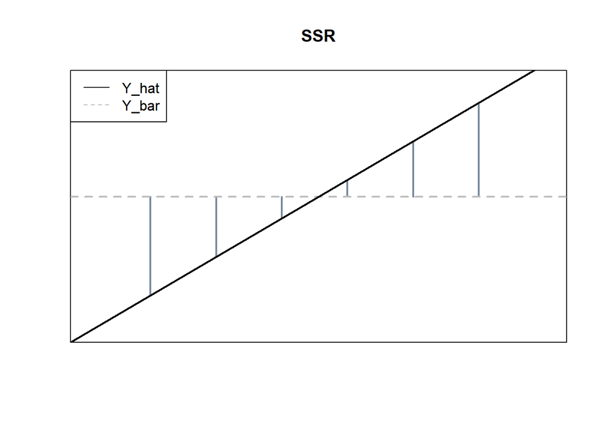

```r
plot(y ~ x, pch=16, col="gray100", xlim=c(0,7), cex=2, yaxt='n', xaxt='n', xlab="", ylab="", main="SSR")
for (i in 1:6){
  lines(rep(x[i]-0.06, 2), c(mean(y),sum(coef(lmr)*c(1,x[i]-0.06))), col="lightslategray", lty=1, lwd=2)
}
abline(h=mean(y), col="gray", lty=2, lwd=2)
abline(lmr, col="black", lwd=2)
legend("topleft", legend = c("Y_hat", "Y_bar"), lty = c(1, 2), col = c("black", "gray"))
```

### SSTO (Total Sum of Squares)

$$= \Sigma(Y_i - \bar{Y})^{2}$$
$$= SSE + SSR$$

Explanation: Measures how much the y-values deviate from the average y-value. (dots (data) to the average y-value)

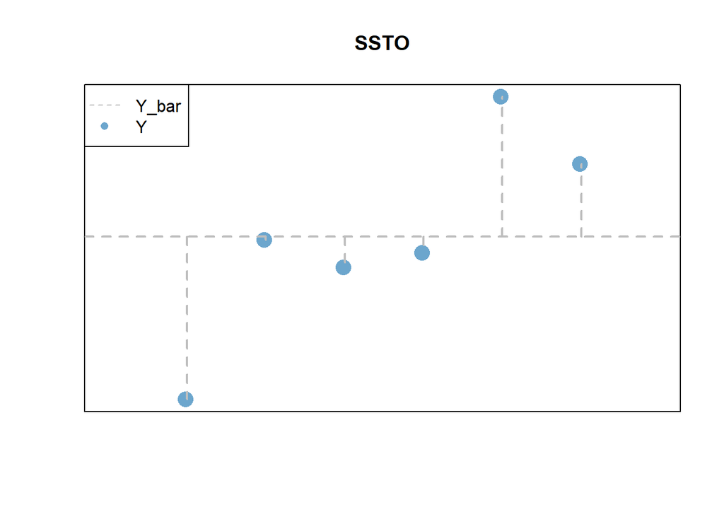

```r
plot(y ~ x, pch=16, col="skyblue3", xlim=c(0,7), cex=2, yaxt='n', xaxt='n', xlab="", ylab="", main="SSTO")
for (i in 1:6){
  lines(rep(x[i]+0.02, 2), c(mean(y),y[i]), col="gray", lty=2, lwd=2)
}
abline(h=mean(y), col="gray", lty=2, lwd=2)
legend("topleft", legend = c("Y_bar", "Y"), lty = c(2, NA), pch = c(NA, 16), col = c("gray", "skyblue3"))
```

### R_squared (coefficient of determination)

$$= \frac{SSR}{SSTO}$$
$$= \frac{\Sigma(\hat{Y_i} - \bar{Y})^{2}}{\Sigma(Y_i - \bar{Y})^{2}}$$
$$= 1 - \frac{SSE}{SSTO}$$
Explanation: Proportion of variation in Y explained by the regression. It is a coefficient that measures how well the estimate regression model describes the actual sample. If R_squared is 1, the estimated regression model perfectly fits to data. If it is 0, the estimated regression model cannot explain the distributed data. 0 $\leq$ $R^2$ $\leq$ 1.

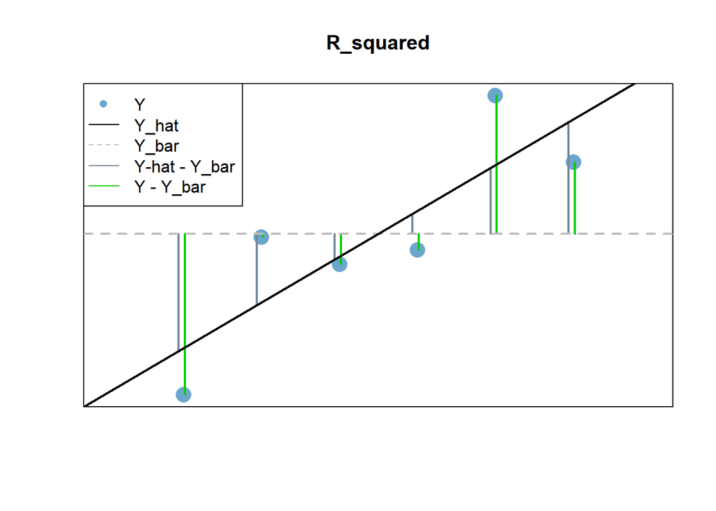

```r
plot(y ~ x, pch=16, col="skyblue3", xlim=c(0,7), cex=2, yaxt='n', xaxt='n', xlab="", ylab="", main="R_squared")
for (i in 1:6){
  lines(rep(x[i]+0.02, 2), c(mean(y),y[i]), col="green3", lty=1, lwd=2)
}
for (i in 1:6){
  lines(rep(x[i]-0.06, 2), c(mean(y),sum(coef(lmr)*c(1,x[i]-0.06))), col="lightslategray", lty=1, lwd=2)
}
abline(h=mean(y), col="gray", lty=2, lwd=2)
abline(lmr, col="black", lwd=2)
legend("topleft", legend = c("Y", "Y_hat", "Y_bar", "Y-hat - Y_bar", "Y - Y_bar"), lty = c(NA, 1, 2, 1, 1), col = c("skyblue3", "black", "gray", "lightslategray", "green3"), pch = c(16, NA, NA, NA, NA))
```

### Adjusted R_squared

$$= 1 - \frac{(1 - R^{2})(n - 1)}{n - p - 1} \quad \text{(n: sample size, p: number of variables)}$$
Explanation: It is a value that adjust R_squared to number of x variables because $R^2$’s value never decrease, but increase or stable when number of x variable is added. So, adjusted $R^2$ complement $R^2$ weakness.

### r (coefficient of correlation)

$$= \sqrt{R^{2}}$$
$$= \frac{\Sigma(x_i - \bar{x})(y_i - \bar{y})}{\sqrt{\Sigma(x_i - \bar{x})^{2}} \sqrt{\Sigma(y_i - \bar{y})^{2}}}$$
Explanation: A measure of association between two continuous variables. When r > 0, if one variable takes a value greater(smaller) than the mean, the other variable takes a value greater(smaller) than the mean. When r < 0, if one variable takes a value greater(smaller) than the mean, the other variable takes a value smaller(greater) than the mean. -1 $\leq$ r $\leq$ 1.

## Insights

r can have a value between -1 and 1. When r is -1 or 1, it means that linear regression model shows 100% correlation, which means if I know one variable’s value, I can know the other variable’s value with 100%.

As $R^2$ is r squared, its value is in between 0 to 1. $R^2$ measures the strenght of the relationship between the model and the dependent variable on 0 to 100%. It evaluates the scatter of the data points around the fitted regression line. When $R^2$ is higher, the smaller differneces between the observed data and the fitted value.

ex) When r = 0.9, then $R^2$ = 0.81. This means that the linear regression model can explain the relationship between X and Y with 81% accuracy.

Residual standard error value is small means that the difference between the estimated values and the actual values is small, $R^2$ gets close to 1.